# Assignment - Lecture 10

Ann-Sophie Frind

2024-05-10

# Preparations

```r
suppressPackageStartupMessages({
  library(GenomicRanges)
  library(epiwraps)
  library(ggplot2)
  library(rGREAT) # Gene Ontology enrichment among genomic regions
})
```

### Download and decompress the following archive:

This contains the bigwig files and peaks (bed) files for three TFs of the CREB family (all restricted to chr1; aligned against the hg38 genome): https://en.wikipedia.org/wiki/CREB.  
The CREB (cAMP Response Element-Binding) family of transcription factors (TFs) includes **CREB**, **CREB3**, and **CREB3L1**. These proteins play crucial roles in regulating gene expression in response to various cellular signals.

- **CREB1 (cAMP Response Element-Binding protein)**: CREB1 is a key transcription factor activated by phosphorylation through various signaling pathways, including cAMP, calcium, and growth factors. It binds to the cAMP response element (CRE) in DNA to regulate genes involved in neuronal plasticity, survival, and metabolism.
- **CREB3**: CREB3 is a transcription factor involved in the unfolded protein response (UPR) and cellular stress. Activated by proteolytic cleavage, it regulates genes crucial for ER stress response, lipid metabolism, and cellular homeostasis under stress conditions.
- **CREB3L1**: CREB3L1 is a transcription factor similar to CREB3, activated by intramembrane proteolysis. It regulates genes involved in the ER stress response, osteoblast differentiation, antiviral response, and cellular adaptation to ER stress, impacting bone formation and antiviral defenses.

```r
options(timeout = 6000)
download.file("https://ethz-ins.org/content/w10.assignment.zip", "w10.assignment.zip")
unzip("w10.assignment.zip")
list.files()
```

This contains the bigwig files and peaks (bed) files for three TFs of the CREB family (all restricted to chr1; aligned against the hg38 genome).

# Clustering and Visualization

… to illustrate the relationship between the binding of the different proteins

#### Prepare the regions and the tracks

Reminder:

- BED Files: These contain information about the **genomic locations** of transcription factor binding sites (peaks). You have BED files for Creb1, Creb3, and Creb3L1.
- bigWig Files: These are used for displaying continuous-valued data in a track format, such as the **binding intensities** of the transcription factors across the genome.

**Tip**: focus on high-confidence peaks (.bed-files) to define the universe of regions.

```r
tracks <- list.files(pattern="bw$") # = binding intensities for all 3 CREBs
peaks <- list.files(pattern="bed$")
# we first import the peaks
peaks <- lapply(peaks, rtracklayer::import.bed)

# we'll focus on the high-quality peaks
peaks <- lapply(peaks, FUN=function(x) x[x$score>800])

# we get the union of non-redundant regions
regions <- reduce(unlist(GRangesList(peaks)))

#regions_CREB1 <- rtracklayer::import.bed("Creb1.bed") # = Genomic locations for each CREB
#regions_CREB3 <- rtracklayer::import.bed("Creb3.bed")
#regions_CREB3L1 <- rtracklayer::import.bed("Creb3L1.bed")
```

#### Plot

```r
ese <- signal2Matrix(tracks, regions, extend=2000) # Expression set
```

```
## Reading Creb1.bw
```

```
## Reading Creb3.bw
```

```
## Reading Creb3L1.bw
```

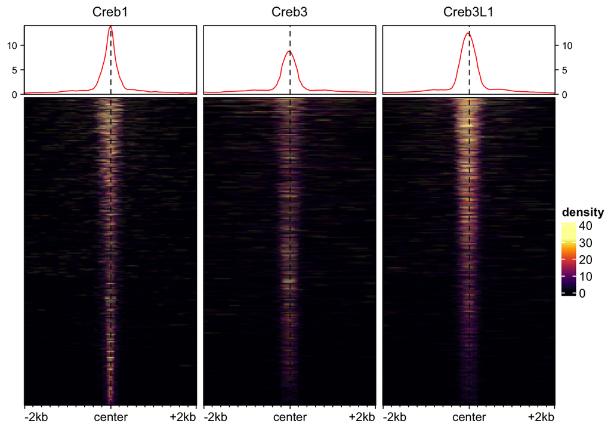

```r
plotEnrichedHeatmaps(ese)
```

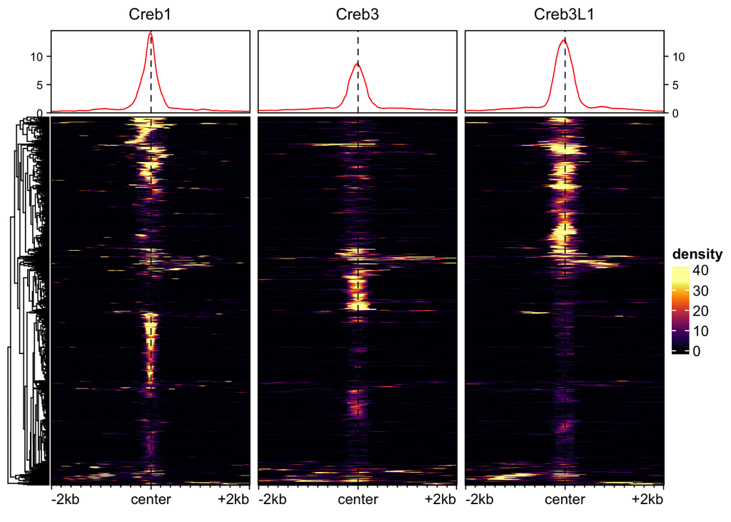

```r
ese2 <- ese[1:1000,] # select the first 1000 rows from the ese object while keeping all columns
plotEnrichedHeatmaps(ese2, cluster_rows = TRUE, show_row_dend=TRUE ) # gives activities of different TFs across the same genomic regions
```

### Clustering

```r
set.seed(123)  # to ensure that it gives the same results everytime
cl <- clusterSignalMatrices(ese, k=4) # dividing data into k=4 clusters
```

```
##   ~70% of the variance explained by clusters
```

```r
table(cl) # states how many items are in each cluster
```

```
## cl
##   1   2   3   4
## 961  80 365 863
```

```r
head(cl)
```

```
## [1] 4 4 1 1 1 4
## Levels: 1 2 3 4
```

```r
length(cl)
```

```
## [1] 2269
```

```r
length(regions)
```

```
## [1] 2269
```

```r
# to make sure the cluster labels stay associated with the corresponding regions/rows
# even if we manipulate the object, put them inside the rowData of the object:
rowData(ese)$cluster <- cl
head(rowData(ese))
```

```
## DataFrame with 6 rows and 1 column
##                     cluster
##                    <factor>
## chr1:778487-779069        4
## chr1:904436-904985        4
## chr1:941785-942096        1
## chr1:943126-943501        1
## chr1:959088-959463        1
## chr1:961148-961904        4
```

Clusters 1 and 4 contain the majority of the regions. About 70% of the variability in the dataset is captured by these clusters, suggesting that the clustering effectively reflects significant patterns or relationships in the data. This approach helps identify regions with similar regulatory characteristics or functional roles, which can be crucial for further genomic analysis or biological research.

#### Plotting the clusters:

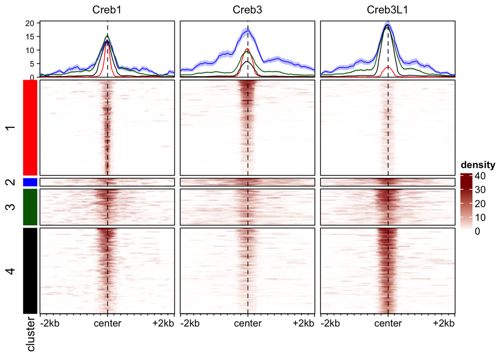

```r
mycolors <- c("1"="red", "2"="blue", "3"="darkgreen", "4"="black")
plotEnrichedHeatmaps(ese, row_split="cluster", mean_color=mycolors, colors=c("white","darkred"))
```

Trying different numbers of clusters:

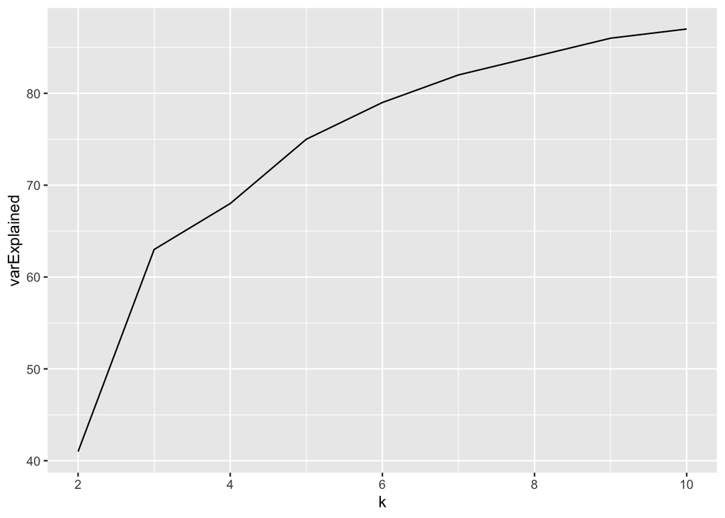

```r
cl2 <- clusterSignalMatrices(ese, k=2:10)
ggplot(cl2$varExplained, aes(k, varExplained)) + geom_line()
```

The graph is useful for guiding decisions on how many clusters to use for further detailed analysis, balancing between too few clusters (oversimplifying the data) and too many clusters (overfitting and complicating the interpretation). Here pivoting points could be set on k=3 or k=5, so I’ll stick with k=4.

Plotting just the averages:

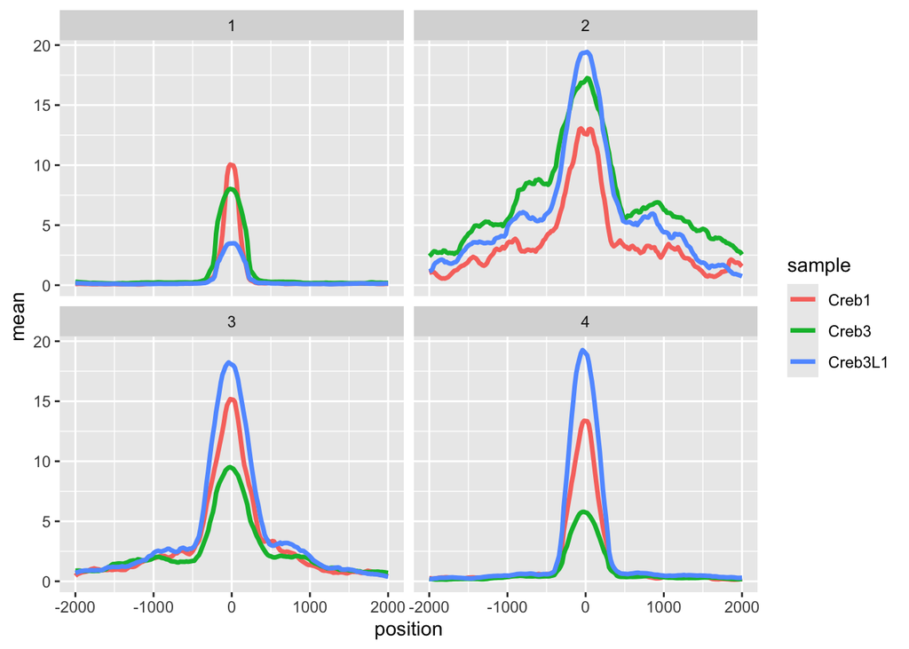

```r
d <- meltSignals(ese, splitBy=cl)
ggplot(d, aes(position, mean, colour=sample)) + geom_line(size=1.2) + facet_wrap(~split)
```

Clustering using relative signal instead: ——-> relevant oder weg damit??

```r
cl <- clusterSignalMatrices(ese, k=4, scaleRows = TRUE)
```

```
##   ~86% of the variance explained by clusters
```

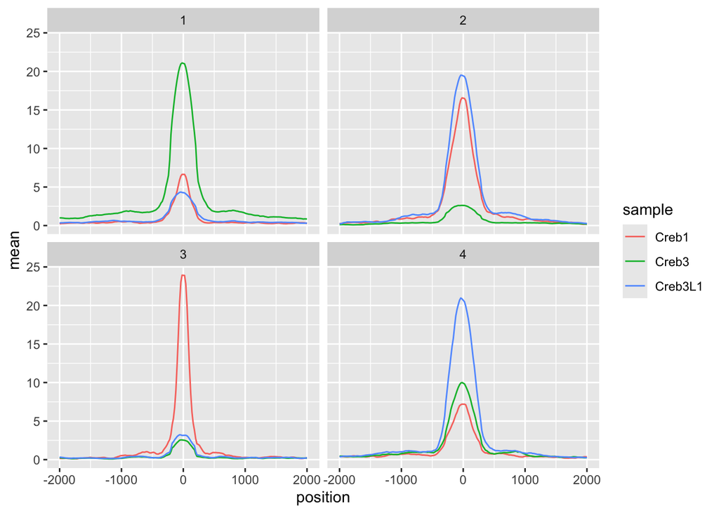

```r
d <- meltSignals(ese, splitBy=cl)
ggplot(d, aes(position, mean, colour=sample)) + geom_line() + facet_wrap(~split)
```

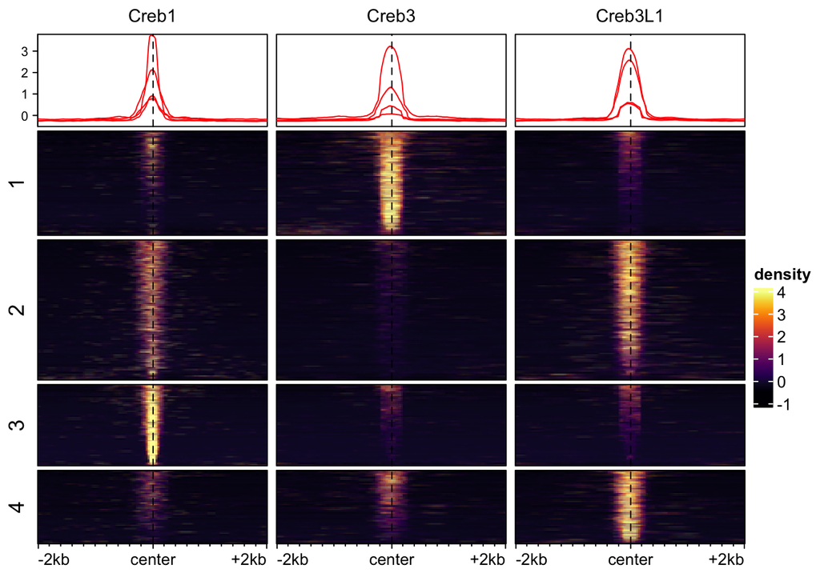

```r
plotEnrichedHeatmaps(ese, row_split = cl, scale_rows = "global")
```

#### Interpretation of clusters

Collectively the graphs show that all three transcription factors have peaks at the center, that indicates **specific and localized binding sites on the genome**. **Creb1** exhibits a very sharp and intense peak especially in cluster 1, suggesting a **strong and specific binding**, while **Creb3 and Creb3L1** show broader peaks, indicating a **less specific binding pattern** that covers wider genomic regions. This could imply that **Creb1 might have a more dominant or direct gene regulatory role**, and Creb3 and Creb3L1 might modulate gene expression more broadly or cooperatively. The overlapping central peaks also suggest potential **competitive or cooperative** interactions among these factors, possibly affecting the same genomic functions or regulatory pathways.

# Enrichment Analysis

In the *great()* function (Genomic Regions Enrichment of Annotations Tool) the following arguments are specified:

- split_regions[[“1”]]: Specifies that the analysis should be performed on the genomic regions in the first cluster.
- gene_sets=“GO:BP”: Defines the set of gene annotations to test against, in this case, “**B**iological **P**rocess” from the **G**ene **O**ntology.
- tss_source=“hg38”: Specifies the transcription start site (TSS) source, indicating the genome version (here, human genome build hg38) used to map genomic coordinates.
- background=regions: This should be a variable or argument specifying the background set of genomic regions against which the enrichment is calculated. Here combined relevant regions from CREB1, CREB3, and CREB1L3
- cores=2: Sets the number of processor cores to use for the analysis, which speeds up the computation.

Find what’s enriched in one cluster with respect to the others:

### Cluster 1

```r
# we first split the regions by cluster:
split_regions <- split(rowRanges(ese), rowData(ese)$cluster)
lengths(split_regions)
```

```
##   1   2   3   4
## 961  80 365 863
```

```r
res1 <- great(split_regions[["1"]], gene_sets="GO:BP", tss_source="hg38", # "Genomic Regions Enrichment of Annotations Tool"
             background=regions, cores=2)
```

```
## * TSS source: TxDb.
```

```
## * check whether TxDb package 'TxDb.Hsapiens.UCSC.hg38.knownGene' is installed.
```

```
## * gene ID type in the extended TSS is 'Entrez Gene ID'.
```

```
## * restrict chromosomes to 'chr1, chr2, chr3, chr4, chr5, chr6, chr7, chr8, chr9, chr10,
##     chr11, chr12, chr13, chr14, chr15, chr16, chr17, chr18, chr19, chr20, chr21, chr22, chrX,
##     chrY, chrM'.
```

```
## * 18100/30601 protein-coding genes left.
```

```
## * update seqinfo to the selected chromosomes.
```

```
## * TSS extension mode is 'basalPlusExt'.
```

```
## * construct the basal domains by extending 5000bp to upstream and 1000bp to downsteram of TSS.
```

```
## * calculate distances to neighbour regions.
```

```
## * extend to both sides until reaching the neighbour genes or to the maximal extension.
```

```
## * use GO:BP ontology with 15517 gene sets (source: org.Hs.eg.db).
```

```
## * check gene ID type in `gene_sets` and in `extended_tss`.
```

```
## * use self-defined background regions.
```

```
## * remove excluded regions from background.
```

```
## * overlap `gr` to background regions (based on midpoint).
```

```
## * in total 961 `gr`.
```

```
## * overlap extended TSS to background regions.
```

```
## * check which genes are in the gene sets.
```

```
## * only take gene sets with size >= 5.
```

```
## * in total 2523 gene sets.
```

```
## * overlap `gr` to every extended TSS.
```

```
## * perform binomial test for each biological term.
```

```r
bp1 <- getEnrichmentTables(res1)
head(bp1)
```

```
##           id                        description genome_fraction
## 1 GO:0040011                         locomotion       0.1151222
## 2 GO:0016477                     cell migration       0.1660602
## 3 GO:2000145        regulation of cell motility       0.1000183
## 4 GO:0009653 anatomical structure morphogenesis       0.2679015
## 5 GO:0040012           regulation of locomotion       0.1063699
## 6 GO:0032501   multicellular organismal process       0.5778207
##   observed_region_hits fold_enrichment      p_value     p_adjust mean_tss_dist
## 1                  174        1.572776 1.407768e-09 3.318110e-06        136877
## 2                  229        1.434982 6.214388e-09 6.296092e-06        117416
## 3                  153        1.591800 8.013694e-09 6.296092e-06        123044
## 4                  336        1.305091 1.561895e-08 7.507982e-06        116862
## 5                  159        1.555446 1.765629e-08 7.507982e-06        131052
## 6                  639        1.150759 1.911238e-08 7.507982e-06        114177
##   observed_gene_hits gene_set_size fold_enrichment_hyper p_value_hyper
## 1                 71            87              1.300294  7.017664e-05
## 2                 99           122              1.292938  3.553236e-06
## 3                 62            73              1.353229  1.774396e-05
## 4                153           207              1.177670  1.648680e-04
## 5                 63            75              1.338387  3.171601e-05
## 6                395           563              1.117870  1.391226e-06
##   p_adjust_hyper
## 1   0.0050541241
## 2   0.0010468722
## 3   0.0027881680
## 4   0.0086354213
## 5   0.0035597446
## 6   0.0006499421
```

We plot the top Biological Processes:

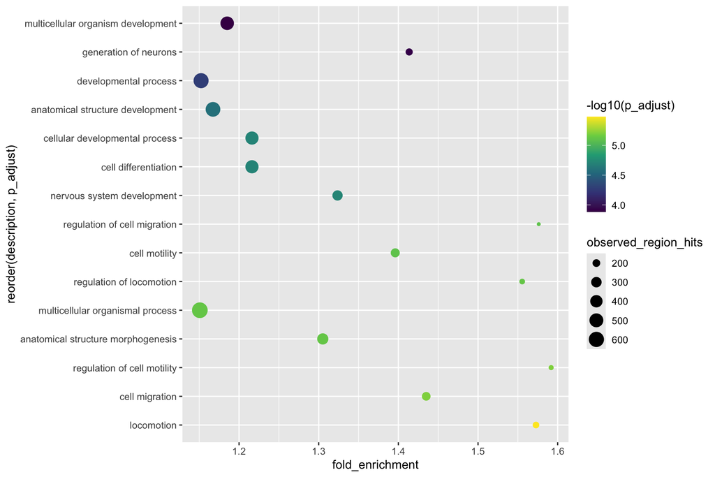

```r
ggplot(head(bp1,15), aes(fold_enrichment, reorder(description, p_adjust),
                        size=observed_region_hits, color=-log10(p_adjust))) +
  geom_point() + scale_color_viridis_c()
```

### Cluster 4

```r
# we first split the regions by cluster:
split_regions <- split(rowRanges(ese), rowData(ese)$cluster)
lengths(split_regions)
```

```
##   1   2   3   4
## 961  80 365 863
```

```r
res4 <- great(split_regions[["4"]], gene_sets="GO:BP", tss_source="hg38",
             background=regions, cores=2)
```

```
## * TSS source: TxDb.
```

```
## * extended_tss is already cached, directly use it.
```

```
## * use GO:BP ontology with 15517 gene sets (source: org.Hs.eg.db).
```

```
## * check gene ID type in `gene_sets` and in `extended_tss`.
```

```
## * use self-defined background regions.
```

```
## * remove excluded regions from background.
```

```
## * overlap `gr` to background regions (based on midpoint).
```

```
## * in total 863 `gr`.
```

```
## * overlap extended TSS to background regions.
```

```
## * check which genes are in the gene sets.
```

```
## * only take gene sets with size >= 5.
```

```
## * in total 2523 gene sets.
```

```
## * overlap `gr` to every extended TSS.
```

```
## * perform binomial test for each biological term.
```

```r
bp4 <- getEnrichmentTables(res4)
head(bp4)
```

```
##           id                           description genome_fraction
## 1 GO:0072089               stem cell proliferation     0.014453272
## 2 GO:0000460               maturation of 5.8S rRNA     0.004656583
## 3 GO:0030203   glycosaminoglycan metabolic process     0.001869210
## 4 GO:0000470                maturation of LSU-rRNA     0.003566876
## 5 GO:0072091 regulation of stem cell proliferation     0.007169306
## 6 GO:0071695       anatomical structure maturation     0.024354842
##   observed_region_hits fold_enrichment    p_value  p_adjust mean_tss_dist
## 1                   21        1.683613 0.01624662 0.9999392         43603
## 2                    9        2.239569 0.02164223 0.9999392         23593
## 3                    5        3.099567 0.02428776 0.9999392          6717
## 4                    7        2.274046 0.03732304 0.9999392          2864
## 5                   11        1.777889 0.05020059 0.9999392         25509
## 6                   29        1.379755 0.05459759 0.9999392         54842
##   observed_gene_hits gene_set_size fold_enrichment_hyper p_value_hyper
## 1                 10            11              1.420647    0.05230227
## 2                  5             5              1.562712    0.10686451
## 3                  5             5              1.562712    0.10686451
## 4                  5             5              1.562712    0.10686451
## 5                  6             7              1.339467    0.21633024
## 6                 14            22              0.994453    0.60914077
##   p_adjust_hyper
## 1      0.7995298
## 2      0.9108688
## 3      0.9108688
## 4      0.9108688
## 5      0.9999065
## 6      0.9999065
```

We plot the top Biological Processes:

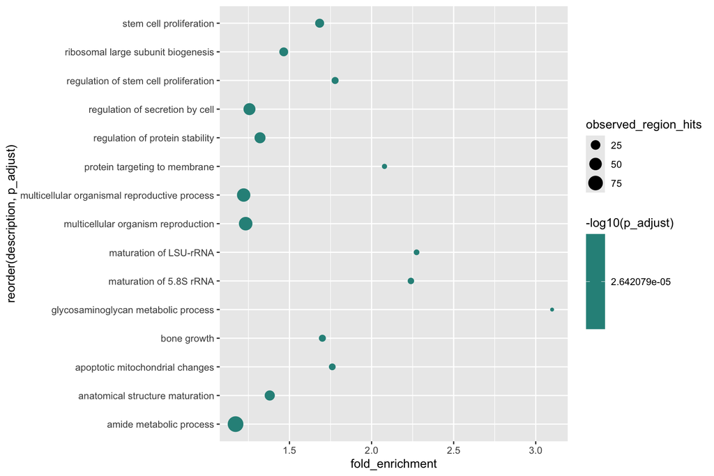

```r
ggplot(head(bp4,15), aes(fold_enrichment, reorder(description, p_adjust),
                        size=observed_region_hits, color=-log10(p_adjust))) +
  geom_point() + scale_color_viridis_c()
```

# Results collection

#### Clustering

Collectively the clustering graphs show that all three transcription factors have peaks at the center, that indicates specific and localized binding sites on the genome. Creb1 exhibits a very sharp and intense peak especially in cluster 1, suggesting a strong and specific binding, while Creb3 and Creb3L1 show broader peaks, indicating a less specific binding pattern that covers wider genomic regions. This could imply that Creb1 might have a more dominant or direct gene regulatory role, and Creb3 and Creb3L1 might modulate gene expression more broadly or cooperatively. The overlapping central peaks also suggest potential competitive or cooperative interactions among these factors, possibly affecting the same genomic functions or regulatory pathways.